# Interpretive vs. Deadpan Analyses

Author

Cameron J. Anderson

# Data Set-up

```r
# load data

load(paste0(here::here(), '/Data/Bootstrap-2024-10-27.RData'))

emoData <- read.csv(paste0(here::here(), '/Data/Ratings.csv'))
#emoData[emoData$composer == 'chopin' & emoData$pieceID == 'm4',] <- NA
#emoData <- na.omit(emoData)

# load dependencies & functions, analyses

source(paste0(here::here(), '/R/Libraries.R'))
source(paste0(here::here(), '/R/Functions2.R'))
source(paste0(here::here(), '/R/Preprocessing.R'))
```

# Power Analysis

We first performed a power analysis to identify how many participants to include in each experiment.

```r
pwrss::pwrss.f.reg(r2 = 0.4, k = 3, power = .9)
```

```
 Linear Regression (F test)
 R-squared Deviation from 0 (zero)
 H0: r2 = 0
 HA: r2 > 0
 ------------------------------
  Statistical power = 0.9
  n = 26
 ------------------------------
 Numerator degrees of freedom = 3
 Denominator degrees of freedom = 21.559
 Non-centrality parameter = 17.04
 Type I error rate = 0.05
 Type II error rate = 0.1
```

# Data Analyses

This code prepares a data frame collapsing across participant ratings.

```r
# create summary data frame
fullDat %>% dplyr::group_by(composer, albumID, condition, key) %>%
  dplyr::summarize(arousal = mean(arousal),
            valence = mean(valence)) -> summaryDat
```

## Circumplex plot (Fig 1)

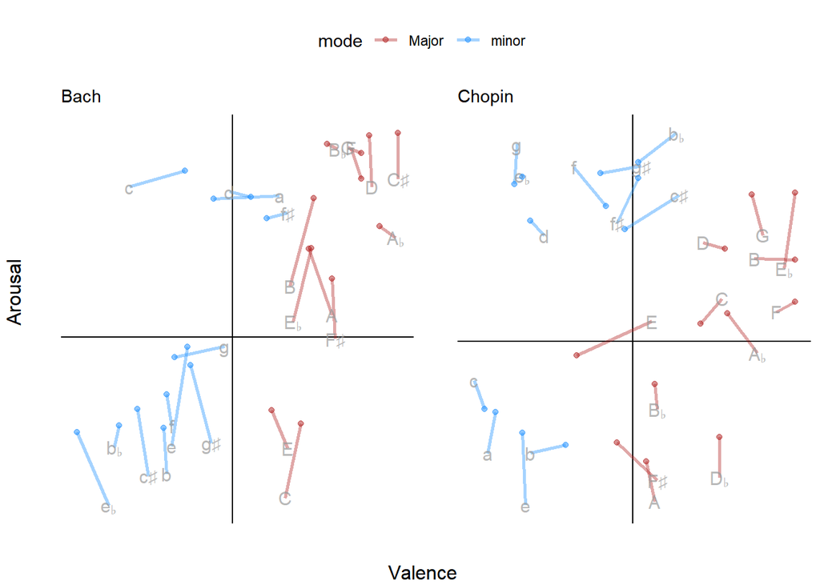

```r
p1 = pairedCircumplex(subset(fullDat, composer == 'bach'),
                      groupCol = 'expID', chosenLvls = c('141', '142')) +
  labs(subtitle='Bach', x = '', y = '') +
  theme(legend.position = 'bottom')
p2 = pairedCircumplex(chop, groupCol = 'expID',
                      chosenLvls = c('155', '137')) +
  labs(subtitle='Chopin', x = '', y = '')

cowplot::get_plot_component(p1, 'guide-box-bottom') -> circLeg

gridExtra::grid.arrange(circLeg,
             p1 + theme(legend.position = 'none'),
             p2 + theme(legend.position = 'none'),
             layout_matrix = circLayout,
             bottom = 'Valence',
             left = 'Arousal')  %>%
    ggsave(filename = paste0(here::here(), '/Figures/Fig 1',
                             Sys.Date(), '.png'),
 width = 7.5, height = 4.5)
```

#### Do deadpan & expressive conditions significantly differ in terms of valence and arousal?

The mean valence rating of deadpan listeners is 4.17 The SD valence rating of deadpan listeners is 1.62 The mean valence rating of expressive listeners is 4.23 The SD valence rating of expressive listeners is 1.65 The mean arousal rating of deadpan listeners is 60.14 The SD arousal rating of deadpan listeners is 26.56 The mean arousal rating of expressive listeners is 55.67 The SD arousal rating of expressive listeners is 27.68

### How similar are valence and arousal ratings?

```r
# overall correlations

cor.test(subset(summaryDat, condition == 'expressive')$valence,
         subset(summaryDat, condition == 'deadpan')$valence) -> t1

cor.test(subset(summaryDat, condition == 'expressive')$arousal,
         subset(summaryDat, condition == 'deadpan')$arousal) -> t2

print(t1)
```

```
    Pearson's product-moment correlation

data:  subset(summaryDat, condition == "expressive")$valence and subset(summaryDat, condition == "deadpan")$valence
t = 22.959, df = 46, p-value < 2.2e-16
alternative hypothesis: true correlation is not equal to 0
95 percent confidence interval:
 0.9276807 0.9769508
sample estimates:
      cor
0.9590286
```

```r
print(t2)
```

```
    Pearson's product-moment correlation

data:  subset(summaryDat, condition == "expressive")$arousal and subset(summaryDat, condition == "deadpan")$arousal
t = 22.464, df = 46, p-value < 2.2e-16
alternative hypothesis: true correlation is not equal to 0
95 percent confidence interval:
 0.9247158 0.9759807
sample estimates:
      cor
0.9573205
```

```r
print(p.adjust(c(t1$p.value, t2$p.value)))
```

```
[1] 1.550960e-26 1.948045e-26
```

```r
remove(t1, t2)
```

```r
# test differences (nonparametric)

wilcox.test(x = subset(summaryDat, condition == "expressive")$valence,
            y = subset(summaryDat, condition == "deadpan")$valence, paired = T,
            exact = F) -> t1
wilcox.test(x = subset(summaryDat, condition == "expressive")$arousal,
            y = subset(summaryDat, condition == "deadpan")$arousal, paired = T, exact = F) -> t2

message('valence')
```

```
valence
```

```r
print(t1)
```

```
    Wilcoxon signed rank test with continuity correction

data:  subset(summaryDat, condition == "expressive")$valence and subset(summaryDat, condition == "deadpan")$valence
V = 601, p-value = 0.3486
alternative hypothesis: true location shift is not equal to 0
```

```r
message('arousal')
```

```
arousal
```

```r
print(t2)
```

```
    Wilcoxon signed rank test with continuity correction

data:  subset(summaryDat, condition == "expressive")$arousal and subset(summaryDat, condition == "deadpan")$arousal
V = 234, p-value = 0.0002882
alternative hypothesis: true location shift is not equal to 0
```

```r
print(paste('Adjusted P valence, arousal: ', p.adjust(c(t1$p.value, t2$p.value))))
```

```
[1] "Adjusted P valence, arousal:  0.348635103687903"
[2] "Adjusted P valence, arousal:  0.000576384719553891"
```

```r
message('effect size valence')
```

```
effect size valence
```

```r
as.numeric(rcompanion::wilcoxonPairedR(x = summaryDat$valence, g = summaryDat$condition, ci = T))
```

```
[1] -0.141 -0.406  0.162
```

```r
message('effect size arousal')
```

```
effect size arousal
```

```r
as.numeric(rcompanion::wilcoxonPairedR(x = summaryDat$arousal, g = summaryDat$condition, ci = T))
```

```
[1] 0.524 0.281 0.719
```

- Arousal exhibits significant differences between conditions.

### How do differences between conditions apply to individual composers?

```r
# comparisons

t1 <- wilcox.test(subset(summaryDat, composer == 'bach' &
                           condition == "expressive")$valence,
                  subset(summaryDat, composer == 'bach' &
                           condition == "deadpan")$valence,
                  paired = T, exact =F)

t2 <- wilcox.test(
                subset(summaryDat,
                         composer == 'chopin' & condition == "expressive")$valence,
                 subset(summaryDat,
                        composer == 'chopin' & condition == "deadpan")$valence,
            paired = T,
            exact = F)

## bach -- arousal significantly differs

t3 <- wilcox.test(subset(summaryDat, composer == 'bach' &
                           condition == "expressive")$arousal,
                  subset(summaryDat, composer == 'bach' &
                           condition == "deadpan")$arousal,
                  paired = T, exact =F)

t4<- wilcox.test(
                subset(summaryDat,
                         composer == 'chopin' & condition == "expressive")$arousal,
                 subset(summaryDat,
                        composer == 'chopin' & condition == "deadpan")$arousal,
            paired = T,
            exact = F)

message('bach valence')
```

```
bach valence
```

```r
print(t1)
```

```
    Wilcoxon signed rank test with continuity correction

data:  subset(summaryDat, composer == "bach" & condition == "expressive")$valence and subset(summaryDat, composer == "bach" & condition == "deadpan")$valence
V = 163, p-value = 0.4559
alternative hypothesis: true location shift is not equal to 0
```

```r
message('chopin valence')
```

```
chopin valence
```

```r
print(t2)
```

```
    Wilcoxon signed rank test with continuity correction

data:  subset(summaryDat, composer == "chopin" & condition == "expressive")$valence and subset(summaryDat, composer == "chopin" & condition == "deadpan")$valence
V = 148.5, p-value = 0.4851
alternative hypothesis: true location shift is not equal to 0
```

```r
message('bach arousal')
```

```
bach arousal
```

```r
print(t3)
```

```
    Wilcoxon signed rank test with continuity correction

data:  subset(summaryDat, composer == "bach" & condition == "expressive")$arousal and subset(summaryDat, composer == "bach" & condition == "deadpan")$arousal
V = 28, p-value = 0.0005177
alternative hypothesis: true location shift is not equal to 0
```

```r
message('chopin arousal')
```

```
chopin arousal
```

```r
print(t4)
```

```
    Wilcoxon signed rank test with continuity correction

data:  subset(summaryDat, composer == "chopin" & condition == "expressive")$arousal and subset(summaryDat, composer == "chopin" & condition == "deadpan")$arousal
V = 98, p-value = 0.1412
alternative hypothesis: true location shift is not equal to 0
```

```r
p.adjust(c(t1$p.value, t2$p.value, t3$p.value, t4$p.value))
```

```
[1] 0.911768954 0.911768954 0.002070788 0.423525754
```

```r
remove(t1, t2, t3, t4)

# Effect sizes:

rcompanion::wilcoxonPairedR(x = subset(summaryDat, composer == 'bach')$valence,
                            g = subset(summaryDat, composer == 'bach')$condition,
                            ci = T) |> as.numeric()
```

```
[1] -0.159 -0.565  0.259
```

```r
rcompanion::wilcoxonPairedR(x = subset(summaryDat, composer == 'chopin')$valence,
                            g = subset(summaryDat, composer == 'chopin')$condition,
                            ci = T) |> as.numeric()
```

```
[1] -0.152 -0.530  0.306
```

```r
rcompanion::wilcoxonPairedR(x = subset(summaryDat, composer == 'bach')$arousal,
                            g = subset(summaryDat, composer == 'bach')$condition,
                            ci = T) |> as.numeric()
```

```
[1] 0.712 0.461 0.841
```

```r
rcompanion::wilcoxonPairedR(x = subset(summaryDat, composer == 'chopin')$arousal,
                            g = subset(summaryDat, composer == 'chopin')$condition,
                            ci = T) |> as.numeric()
```

```
[1]  0.3040 -0.0935  0.6430
```

### Which features predict valence and arousal differences?

To assess this, we’ll calculate the percent difference of valence and arousal ratings between conditions,

$$d(x, y) = \frac{|x-y|}{[\frac{(x+y)}{2}]}*100,$$

where $x$ represents ratings in the expressive condition averaged by piece and $y$ represents ratings in the deadpan condition averaged by piece.

```r
# first calculate averaged values per piece in each condition
expressive %>%
  dplyr::group_by(composer, key) %>%
  dplyr::summarize(valence = mean(valence),
            arousal = mean(arousal),
            arPerf = mean(arPerf),
            pitchHeight = mean(pitchHeight),
            rms = mean(rms),
            mode = unique(mode)) -> expressiveRatingsAvg
deadpan %>%
  dplyr::group_by(composer, key) %>%
  dplyr::summarize(valence = mean(valence),
            arousal = mean(arousal)) -> deadpanRatingsAvg
# now calculate percentage difference in ratings:

expressiveRatingsAvg$valenceDiff <- .getPercentDifference(expressiveRatingsAvg$valence, deadpanRatingsAvg$valence)
expressiveRatingsAvg$arousalDiff <- .getPercentDifference(expressiveRatingsAvg$arousal, deadpanRatingsAvg$arousal)
```

```r
summary(expressiveRatingsAvg$valenceDiff)
```

```
   Min. 1st Qu.  Median    Mean 3rd Qu.    Max.
  0.000   2.389   5.056   6.656   7.729  24.779
```

```r
summary(expressiveRatingsAvg$arousalDiff)
```

```
   Min. 1st Qu.  Median    Mean 3rd Qu.    Max.
 0.2507  3.9333 11.4433 16.0279 23.3064 54.2876
```

**Percent differences by mode**

```r
expressiveRatingsAvg %>%
  dplyr::group_by(mode) %>%
  dplyr::summarize(meanValenceDiff = mean(valenceDiff),
            sdValenceDiff=sd(valenceDiff),
            meanArousalDiff = mean(arousalDiff),
            sdArousalDiff=sd(arousalDiff))
```

```
# A tibble: 2 × 5
  mode  meanValenceDiff sdValenceDiff meanArousalDiff sdArousalDiff
  <chr>           <dbl>         <dbl>           <dbl>         <dbl>
1 Major            4.71          5.16            15.4          12.3
2 minor            8.60          6.62            16.7          17.7
```

#### What cues explain differences?

First, we examine differences across major and minor pieces:

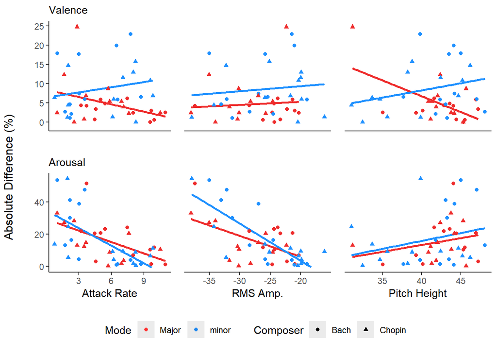

```r
# now valence...

percentCorrelationPlot(expressiveRatingsAvg,
                     y = expressiveRatingsAvg$valenceDiff,
                     ylim = c(-1,25),
                     x = expressiveRatingsAvg$arPerf,
                     axis.text.x = element_blank(),
                     axis.ticks.x = element_blank(),
                     legend.position = 'none')+labs(subtitle = 'Valence') -> cp1
percentCorrelationPlot(expressiveRatingsAvg,
                       y = expressiveRatingsAvg$valenceDiff,
                       ylim = c(-1,25),
                       x = expressiveRatingsAvg$rms,
                       axis.text.y = element_blank(),
                       axis.ticks.y = element_blank(),
                       axis.title.y = element_blank(),
                       axis.line.y = element_blank(),
                       axis.text.x = element_blank(),
                       axis.ticks.x = element_blank(),
                       legend.position = 'none')+labs(subtitle = ' ') -> cp2
percentCorrelationPlot(expressiveRatingsAvg,
                       y = expressiveRatingsAvg$valenceDiff,
                       ylim = c(-1,25),
                       x = expressiveRatingsAvg$pitchHeight,
                       axis.text.y = element_blank(),
                       axis.ticks.y = element_blank(),
                       axis.title.y = element_blank(),
                       axis.line.y = element_blank(),
                       axis.text.x = element_blank(),
                       axis.ticks.x = element_blank(),
                       legend.position = 'none')+labs(subtitle = ' ') -> cp3
  ## OVER AROUSAL

percentCorrelationPlot(expressiveRatingsAvg,
                     y = expressiveRatingsAvg$arousalDiff,
                     x = expressiveRatingsAvg$arPerf,
                     xLab = 'Attack Rate',
                     legend.position = 'none')+labs(subtitle = 'Arousal') -> cp4
percentCorrelationPlot(expressiveRatingsAvg,
                     y = expressiveRatingsAvg$arousalDiff,
                     x = expressiveRatingsAvg$rms,
                     xLab = 'RMS Amp.',
                     axis.text.y = element_blank(),
                     axis.ticks.y = element_blank(),
                     axis.title.y = element_blank(),
                     axis.line.y = element_blank(),
                     legend.position = 'none')+labs(subtitle = ' ') -> cp5
percentCorrelationPlot(expressiveRatingsAvg,
                     y = expressiveRatingsAvg$arousalDiff,
                     x = expressiveRatingsAvg$pitchHeight,
                     xLab = 'Pitch Height',
                     axis.text.y = element_blank(),
                     axis.ticks.y = element_blank(),
                     axis.title.y = element_blank(),
                     axis.line.y = element_blank(),
                     legend.position = 'none')+labs(subtitle = ' ') -> cp6
grid.arrange(percentLegend,
             cp1, cp2, cp3, cp4, cp5, cp6,
             left = 'Absolute Difference (%)',
            # ncol = 3, nrow = 2,
             layout_matrix = pctCorLay) -> cuePercentPlot
```

```r
 ggsave(filename = paste0(here::here(),
                          '/Figures/Fig 2', Sys.Date(), '.png'),
        plot = cuePercentPlot,
        width = 7.5, height = 4.5)
```

```r
diffsMaj <- subset(expressiveRatingsAvg, mode == 'Major')
diffsMin <- subset(expressiveRatingsAvg, mode == 'minor')


cor.test(diffsMin$arPerf, diffsMin$valenceDiff) -> t1
cor.test(diffsMaj$arPerf, diffsMaj$valenceDiff) -> t2
cor.test(diffsMin$rms, diffsMin$valenceDiff) -> t3
cor.test(diffsMaj$rms, diffsMaj$valenceDiff) -> t4
cor.test(diffsMin$pitchHeight, diffsMin$valenceDiff) -> t5
cor.test(diffsMaj$pitchHeight, diffsMaj$valenceDiff) -> t6
message("arPerf, valence, minor")
```

```
arPerf, valence, minor
```

```r
print(t1)
```

```
    Pearson's product-moment correlation

data:  diffsMin$arPerf and diffsMin$valenceDiff
t = 0.98498, df = 22, p-value = 0.3353
alternative hypothesis: true correlation is not equal to 0
95 percent confidence interval:
 -0.2157691  0.5622957
sample estimates:
      cor
0.2055158
```

```r
message("arPerf, valence, major")
```

```
arPerf, valence, major
```

```r
print(t2)
```

```
    Pearson's product-moment correlation

data:  diffsMaj$arPerf and diffsMaj$valenceDiff
t = -1.7995, df = 22, p-value = 0.08567
alternative hypothesis: true correlation is not equal to 0
95 percent confidence interval:
 -0.66543893  0.05283688
sample estimates:
       cor
-0.3581945
```

```r
message("rms, valence, minor")
```

```
rms, valence, minor
```

```r
print(t3)
```

```
    Pearson's product-moment correlation

data:  diffsMin$rms and diffsMin$valenceDiff
t = 0.56515, df = 22, p-value = 0.5777
alternative hypothesis: true correlation is not equal to 0
95 percent confidence interval:
 -0.2981590  0.4989452
sample estimates:
      cor
0.1196259
```

```r
message("arPerf, valence, major")
```

```
arPerf, valence, major
```

```r
print(t4)
```

```
    Pearson's product-moment correlation

data:  diffsMaj$rms and diffsMaj$valenceDiff
t = 0.37485, df = 22, p-value = 0.7114
alternative hypothesis: true correlation is not equal to 0
95 percent confidence interval:
 -0.3344807  0.4680211
sample estimates:
       cor
0.07966506
```

```r
message("ph, valence, minor")
```

```
ph, valence, minor
```

```r
print(t5)
```

```
    Pearson's product-moment correlation

data:  diffsMin$pitchHeight and diffsMin$valenceDiff
t = 1.3112, df = 22, p-value = 0.2033
alternative hypothesis: true correlation is not equal to 0
95 percent confidence interval:
 -0.1505212  0.6067267
sample estimates:
      cor
0.2692227
```

```r
message("ph, valence, major")
```

```
ph, valence, major
```

```r
print(t6)
```

```
    Pearson's product-moment correlation

data:  diffsMaj$pitchHeight and diffsMaj$valenceDiff
t = -3.2975, df = 22, p-value = 0.003281
alternative hypothesis: true correlation is not equal to 0
95 percent confidence interval:
 -0.7942528 -0.2236067
sample estimates:
       cor
-0.5751258
```

```r
print(p.adjust(c(t1$p.value, t2$p.value, t3$p.value,
           t4$p.value, t5$p.value, t6$p.value)))
```

```
[1] 1.00000000 0.42837240 1.00000000 1.00000000 0.81327566 0.01968828
```

```r
remove(t1,t2,t3,t4,t5,t6)


cor.test(diffsMin$arPerf, diffsMin$arousalDiff) -> t1
cor.test(diffsMaj$arPerf, diffsMaj$arousalDiff) -> t2
cor.test(diffsMin$rms, diffsMin$arousalDiff) -> t3
cor.test(diffsMaj$rms, diffsMaj$arousalDiff) -> t4
cor.test(diffsMin$pitchHeight, diffsMin$arousalDiff) -> t5
cor.test(diffsMaj$pitchHeight, diffsMaj$arousalDiff) -> t6

message("arPerf, arousal, minor")
```

```
arPerf, arousal, minor
```

```r
print(t1)
```

```
    Pearson's product-moment correlation

data:  diffsMin$arPerf and diffsMin$arousalDiff
t = -3.7441, df = 22, p-value = 0.001124
alternative hypothesis: true correlation is not equal to 0
95 percent confidence interval:
 -0.8207104 -0.2945958
sample estimates:
       cor
-0.6238543
```

```r
message("arPerf, arousal, major")
```

```
arPerf, arousal, major
```

```r
print(t2)
```

```
    Pearson's product-moment correlation

data:  diffsMaj$arPerf and diffsMaj$arousalDiff
t = -3.1692, df = 22, p-value = 0.004443
alternative hypothesis: true correlation is not equal to 0
95 percent confidence interval:
 -0.7857873 -0.2021031
sample estimates:
      cor
-0.559856
```

```r
message("rms, arousal, minor")
```

```
rms, arousal, minor
```

```r
print(t3)
```

```
    Pearson's product-moment correlation

data:  diffsMin$rms and diffsMin$arousalDiff
t = -6.0159, df = 22, p-value = 4.695e-06
alternative hypothesis: true correlation is not equal to 0
95 percent confidence interval:
 -0.9043316 -0.5649682
sample estimates:
       cor
-0.7886309
```

```r
message("rms, arousal, major")
```

```
rms, arousal, major
```

```r
print(t4)
```

```
    Pearson's product-moment correlation

data:  diffsMaj$rms and diffsMaj$arousalDiff
t = -3.0429, df = 22, p-value = 0.00597
alternative hypothesis: true correlation is not equal to 0
95 percent confidence interval:
 -0.7770461 -0.1804743
sample estimates:
       cor
-0.5442483
```

```r
message("ph, arousal, minor")
```

```
ph, arousal, minor
```

```r
print(t5)
```

```
    Pearson's product-moment correlation

data:  diffsMin$pitchHeight and diffsMin$arousalDiff
t = 1.2864, df = 22, p-value = 0.2117
alternative hypothesis: true correlation is not equal to 0
95 percent confidence interval:
 -0.1554976  0.6034968
sample estimates:
      cor
0.2644898
```

```r
message("ph, arousal, major")
```

```
ph, arousal, major
```

```r
print(t6)
```

```
    Pearson's product-moment correlation

data:  diffsMaj$pitchHeight and diffsMaj$arousalDiff
t = 1.202, df = 22, p-value = 0.2421
alternative hypothesis: true correlation is not equal to 0
95 percent confidence interval:
 -0.1724145  0.5923277
sample estimates:
      cor
0.2482482
```

```r
print(round(p.adjust(c(t1$p.value, t2$p.value, t3$p.value,
           t4$p.value, t5$p.value, t6$p.value)), 5))
```

```
[1] 0.00562 0.01777 0.00003 0.01791 0.42337 0.42337
```

```r
remove(t1,t2,t3,t4,t5,t6)
```

## **Beta Regression**

Perform beta regression to assess significance of differences while dealing with positive (0,1) data:

Create transformation function because data can include 0 and 1 in range:

$$(y * (n - 1) + 0.5)/n$$

```r
arousalDiffB = betaTransform(expressiveRatingsAvg$arousalDiff)
valenceDiffB = betaTransform(expressiveRatingsAvg$valenceDiff)

# center values of attack rate, rms, pitch height

expressiveRatingsAvg2 <- expressiveRatingsAvg

expressiveRatingsAvg2$arPerf <- expressiveRatingsAvg$arPerf - mean(expressiveRatingsAvg$arPerf)
expressiveRatingsAvg2$pitchHeight <- expressiveRatingsAvg$pitchHeight - mean(expressiveRatingsAvg$pitchHeight)
expressiveRatingsAvg2$rms <- expressiveRatingsAvg$rms - mean(expressiveRatingsAvg$rms)
expressiveRatingsAvg2$mode <- as.numeric(factor(expressiveRatingsAvg$mode)) - 1.5
```

```r
set.seed(123)

bregAro = betareg::betareg(
  arousalDiffB ~ arPerf + rms + pitchHeight + mode,
  data = expressiveRatingsAvg2)
bregVal = betareg::betareg(
  valenceDiffB ~ arPerf + rms + pitchHeight + mode + (arPerf*mode) +
      (rms*mode) + (pitchHeight*mode),
    data = expressiveRatingsAvg2)
```

```r
summary(bregAro)
```

```
Call:
betareg::betareg(formula = arousalDiffB ~ arPerf + rms + pitchHeight +
    mode, data = expressiveRatingsAvg2)

Standardized weighted residuals 2:
    Min      1Q  Median      3Q     Max
-3.4643 -0.4840  0.1131  0.8046  1.5661

Coefficients (mean model with logit link):
            Estimate Std. Error z value Pr(>|z|)
(Intercept) -1.74739    0.11476 -15.226  < 2e-16 ***
arPerf      -0.10900    0.04676  -2.331  0.01976 *
rms         -0.07515    0.02362  -3.181  0.00147 **
pitchHeight  0.01642    0.02492   0.659  0.50999
mode         0.08866    0.21422   0.414  0.67898

Phi coefficients (precision model with identity link):
      Estimate Std. Error z value Pr(>|z|)
(phi)   12.551      2.599   4.829 1.37e-06 ***
---
Signif. codes:  0 '***' 0.001 '**' 0.01 '*' 0.05 '.' 0.1 ' ' 1

Type of estimator: ML (maximum likelihood)
Log-likelihood: 53.46 on 6 Df
Pseudo R-squared: 0.4517
Number of iterations: 23 (BFGS) + 2 (Fisher scoring)
```

```r
summary(bregVal)
```

```
Call:
betareg::betareg(formula = valenceDiffB ~ arPerf + rms + pitchHeight +
    mode + (arPerf * mode) + (rms * mode) + (pitchHeight * mode), data = expressiveRatingsAvg2)

Standardized weighted residuals 2:
    Min      1Q  Median      3Q     Max
-2.5159 -0.7057  0.1208  0.7651  1.9655

Coefficients (mean model with logit link):
                 Estimate Std. Error z value Pr(>|z|)
(Intercept)      -2.47515    0.09839 -25.157  < 2e-16 ***
arPerf           -0.01939    0.03941  -0.492 0.622796
rms               0.01302    0.02214   0.588 0.556576
pitchHeight      -0.01987    0.02143  -0.927 0.353824
mode              0.38879    0.18193   2.137 0.032593 *
arPerf:mode       0.17418    0.07901   2.205 0.027483 *
rms:mode         -0.02529    0.04429  -0.571 0.567936
pitchHeight:mode  0.15243    0.04310   3.537 0.000405 ***

Phi coefficients (precision model with identity link):
      Estimate Std. Error z value Pr(>|z|)
(phi)   32.870      6.898   4.765 1.88e-06 ***
---
Signif. codes:  0 '***' 0.001 '**' 0.01 '*' 0.05 '.' 0.1 ' ' 1

Type of estimator: ML (maximum likelihood)
Log-likelihood: 88.88 on 9 Df
Pseudo R-squared: 0.3118
Number of iterations: 27 (BFGS) + 3 (Fisher scoring)
```

#### Which pieces significantly differ?

Next we employ a bootstrap approach to assess how many pieces significantly differed in valence and arousal

```r
# fullDat$pieceID = paste0(fullDat$pieceID,
#                          substr(fullDat$composer, 1, 1))
# set.seed(1)
# bootstrapCircumplexDifference(
#                  subset(fullDat, condition == 'expressive'),
#                  subset(fullDat, condition == 'deadpan'),
#                  returnSummary = F, replications = 10000,
#                sampleSize = 30,
#                xlimsVal = c(-1.5,1.5),
#                xlimsAro = c(-1.5,1.5),
#                ylimsVal = c(-1.5,1.5),
#                ylimsAro = c(-1.5,1.5), scaleVars = F) -> bootData
# save(bootData,
#      file = paste0(here::here(),
#                    '/Data/Bootstrap',
#                    Sys.Date(), '.RData')
# )
```

# Coefficients of Variation

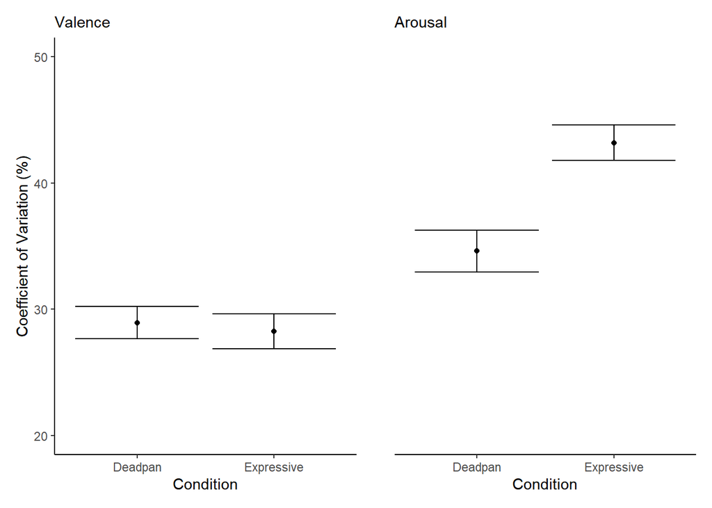

```r
expressCVSig <- data.frame(
  group = c('Expressive', 'Deadpan'),
  meanCVVal = c(mean(bootData$valenceA_cv), mean(bootData$valenceB_cv)),
  lciCVVal = c(quantile(bootData$valenceA_cv, c(0.025)),
               quantile(bootData$valenceB_cv, c(0.025))),
  uciCVVal = c(quantile(bootData$valenceA_cv, c(0.975)),
               quantile(bootData$valenceB_cv, c(0.975))),
  meanCVAro = c(mean(bootData$arousalA_cv),mean(bootData$arousalB_cv)),
  lciCVAro = c(quantile(bootData$arousalA_cv, c(0.025)),
               quantile(bootData$arousalB_cv, c(0.025))),
  uciCVAro = c(quantile(bootData$arousalA_cv, c(0.975)),
               quantile(bootData$arousalB_cv, c(0.975)))
)

ggplot(expressCVSig, aes(x = group, y = meanCVVal*100,
                         ymin = lciCVVal*100, ymax = uciCVVal*100)) +
  geom_point() +
  geom_errorbar() +
  ylim(20, 50) +
  theme_classic()+
  labs(y = 'Coefficient of Variation (%)',
       x = 'Condition', subtitle='Valence') +

ggplot(expressCVSig,
       aes(x = group,
           y = meanCVAro*100,
          ymin = lciCVAro*100,
          ymax = uciCVAro*100))+
  geom_point()+ geom_errorbar()+ylim(20,50) +
  theme_classic() +
  labs(y = '', x = 'Condition', subtitle='Arousal') +
  theme(axis.ticks.y = element_blank(),
        axis.text.y = element_blank(),
        axis.line.y = element_blank())
```

```r
ggsave(filename = paste0(here::here(), '/Figures/Fig 4', Sys.Date(), '.png'))
```

```r
expressCVSig[,2:ncol(expressCVSig)] <- apply(
  expressCVSig[,2:ncol(expressCVSig)],2,
      function(x) round(as.numeric(x)*100, 4))

expressCVSig
```

```
       group meanCVVal lciCVVal uciCVVal meanCVAro lciCVAro uciCVAro
1 Expressive   28.2422  26.8686  29.6420   43.1903  41.7918  44.6197
2    Deadpan   28.9315  27.6538  30.2424   34.6069  32.9538  36.2531
```

# Plot differences

```r
bootPlotDF$key <- nameKeysSimple(
  substr(bootPlotDF$pieceID, 1, nchar(bootPlotDF$pieceID)-1))

bootPlotDF$composer <- as.factor(
  substr(bootPlotDF$pieceID,
       nchar(bootPlotDF$pieceID),
             nchar(bootPlotDF$pieceID)
       )
  )

levels(bootPlotDF$composer) = c('bach', 'chopin')

# temporarily change key back to a character vector to replace c# value with db

bootPlotDF$key = as.character(bootPlotDF$key)
bootPlotDF$key[bootPlotDF$composer == 'chopin' &
             bootPlotDF$key == 'C#'] <- 'Db'
# now convert back to factor
bootPlotDF$key = as.factor(bootPlotDF$key)

bootPlotDF$key = prettyKeyCol(bootPlotDF$key)
```

```r
bootPlotDF$sigDifValence <- sign(bootPlotDF$changeValenceLCI) == sign(bootPlotDF$changeValenceUCI)
bootPlotDF$sigDifArousal <- sign(bootPlotDF$changeArousalLCI) == sign(bootPlotDF$changeArousalUCI)
summary(bootPlotDF$sigDifArousal)
```

```
   Mode   FALSE    TRUE
logical      27      21
```

```r
summary(bootPlotDF$sigDifValence)
```

```
   Mode   FALSE    TRUE
logical      44       4
```

- 21 pieces significantly differed in arousal, 13 of which were by Bach
- 4 pieces differed significantly in valence

```r
# change dimensions for easy visualization
wideDat <- summaryDat[,!colnames(summaryDat) == 'albumID'] %>%
  tidyr::pivot_wider(names_from = 'condition',
              values_from = c('valence', 'arousal'))

wideDat$mode <- factor(wideDat$key == tolower(wideDat$key))
levels(wideDat$mode) <- c('Major', 'minor')


# show ids where difference is significant

corrSigPlot <- data.frame()

for(thisComposer in c('bach', 'chopin')) {
  # subset by composer
  wideDatSS = subset(wideDat, composer == thisComposer)
  # subset bootstrap simulations
  bootPlotSS = subset(bootPlotDF, composer == thisComposer)
  # check which keys yield sig difference in bootplot
  wideDatSS$labelsValence = wideDatSS$key %in% bootPlotSS$key[bootPlotSS$sigDifValence == T]
  wideDatSS$labelsArousal = wideDatSS$key %in% bootPlotSS$key[bootPlotSS$sigDifArousal == T]
  # bind to data frame
  corrSigPlot <- rbind(corrSigPlot, wideDatSS)
}
# hide non-significant key signatures for valence and change mode colour to grey
corrSigPlot$key2 <- corrSigPlot$key
corrSigPlot$key2[!corrSigPlot$labelsValence] <- ''
corrSigPlot$mode2 <- corrSigPlot$mode
levels(corrSigPlot$mode2[!corrSigPlot$labelsValence]) <- c('*', '*')
corrSigPlot$key3 <- corrSigPlot$key
corrSigPlot$key3[!corrSigPlot$labelsArousal] <- ''
corrSigPlot$mode3 <- corrSigPlot$mode
levels(corrSigPlot$mode3[!corrSigPlot$labelsArousal]) <- c('*', '*')
```

```r
# now plot figures:
corrSigPlot %>%
  ggplot(aes(x = valence_deadpan, y = valence_expressive,
             label = key2, alpha = mode2)
         ) +
  geom_smooth(method='lm',linetype = 1,color = 'grey50', se = F, alpha = 0.7) +
  geom_abline(color = 'grey', linetype = 2) +
  geom_point(color = 'grey',
             aes(shape = composer, color = mode2, alpha = mode2)
             ) +
  geom_point(
    data = subset(corrSigPlot, !is.na(corrSigPlot$mode2)),
             aes(shape = composer, color = mode2, alpha = mode2)
    ) +
  geom_text_repel(aes(color = mode2, alpha = mode2), max.overlaps = 12) +
  theme_classic() +
  scale_colour_manual(values = c('firebrick1', 'dodgerblue2')) +
  scale_alpha_manual(values = c(1,1,0.2)) +
  labs(x='Deadpan Rating',y='Expressive Rating') +
  ggtitle('Valence') +
  theme(legend.position = 'none') -> cc1

corrSigPlot %>%
  ggplot(aes(x = arousal_deadpan, y = arousal_expressive,
             label = key3, alpha = mode3)) +
  geom_smooth(method='lm',linetype = 1,color = 'grey50', se = F, alpha = 0.7)+
  geom_abline(color = 'grey', linetype = 2)+
  geom_point(color = 'grey', aes(shape = composer, color = mode3, alpha = mode3))+
  geom_point(data = subset(corrSigPlot, !is.na(corrSigPlot$mode3)),
             aes(shape = composer, color = mode3, alpha = mode3)
             )+
  geom_text_repel(aes(color = mode3, alpha = mode3), max.overlaps = 15, nudge_y = 0.2)+
  theme_classic()+
  scale_colour_manual(values = c('firebrick1', 'dodgerblue2'))+
  scale_alpha_manual(values = c(1,1,0.2))+
  scale_y_continuous(position = 'right')+
  labs(x='Deadpan Rating',y='Expressive Rating')+
  ggtitle('Arousal') +
  theme(legend.position = 'none') -> cc2
```

```r
# layout figures...
cc1<-cc1 +
  xlim(1,7) +
  ylim(1,7) +
  labs(x='Deadpan Rating',
       y='Expressive Rating')

cc2<- cc2 +
  xlim(1,100) +
  ylim(1,100) +
  labs(x='Deadpan Rating',
       y='Expressive Rating')
```

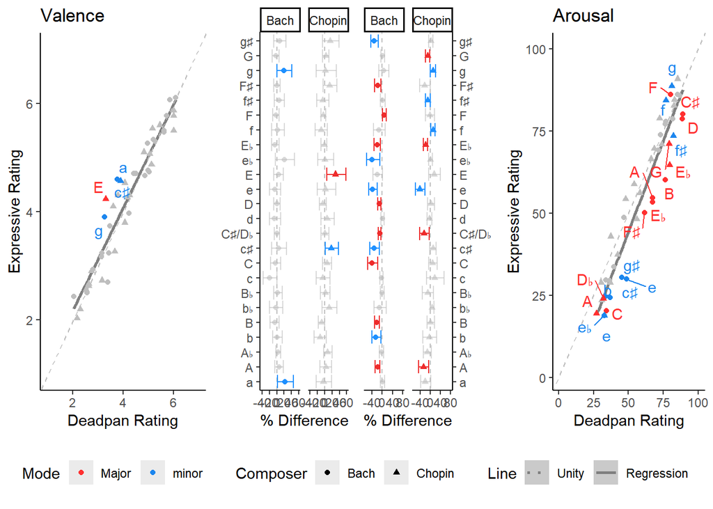

```r
grid.arrange(correlationLegend,
             cc1,
             bs1+theme(axis.title.y = element_blank()),
             cc2,
             bs2+theme(axis.title.y = element_blank()),
             layout_matrix = corrSigLayout) -> all_corr_plots
```

```r
ggsave(paste0(here::here(), '/Figures/Fig 3', Sys.Date(), '.png'), plot = all_corr_plots,
       height = 5, width = 12.5, units = 'in')
```

#### Supplemental Analyses

- This analyses how uncentered estimates contributed to multicollinearity with mode

  ```r
  # convert mode to numeric variable for point-biserial correlation:
  x = as.numeric(factor(expressiveRatingsAvg$mode))
  # define uncentered pitch height
  z = expressiveRatingsAvg$pitchHeight
  # define uncentered attack rate
  w = expressiveRatingsAvg$arPerf
  # define interaction between mode and uncentered pitch height
  xz = x*z
  # define interaction between mode and uncentered attack rate
  xw = x*w
  # define mean-centered pitch height
  z_c =  z - mean(z)
  # define mean-centered attack rate
  w_c = w - mean(w)
  # define interaction between mean-centered mode and pitch height
  xz_c = x*z_c
  # define interaction between mean-centered mode and attack rate
  xw_c = x*w_c
  ```

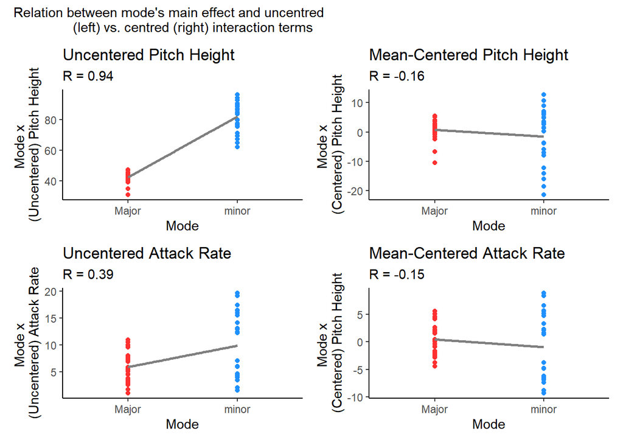

```r
#plot each relation between mode and interaction terms
plotCorrelation(x, xz, xLab = 'Mode', yLab = 'Mode x \n(Uncentered) Pitch Height')+
  labs(title = 'Uncentered Pitch Height')+

plotCorrelation(x, xz_c, xLab = 'Mode', yLab = 'Mode x \n(Centered) Pitch Height')+
  labs(title = 'Mean-Centered Pitch Height')+

plotCorrelation(x, xw, xLab = 'Mode', yLab = 'Mode x \n(Uncentered) Attack Rate')+
  labs(title = 'Uncentered Attack Rate')+

plotCorrelation(x, xw_c, xLab = 'Mode', yLab = 'Mode x \n(Centered) Pitch Height')+
  labs(title = 'Mean-Centered Attack Rate')+

plot_annotation(subtitle = "Relation between mode's main effect and uncentred
                (left) vs. centred (right) interaction terms")
```

```r
ggsave(paste0(here::here(),
              '/Figures/SupplementalFig-',
              Sys.Date(),
              '.png'))
```

Correlation between mode and (i) mode x pitch height interaction term (top); (ii) mode x attack rate interaction term (bottom). Left: pitch height and attack rate uncentered; right: pitch height and attack rate centered at respective mean value.